# 시간과 요일에 따른 따릉이 수요 예측 및 재배치

## 1. 연구배경

문명이 발전함과 동시에 인간은 더욱 높은 편익을 추구하기 위해 기술을 발달시켰다. 편리한 삶을 위해 인간은 스마트폰, 컴퓨터, 자동차 등을 발명하였고 현재 우리 삶의 일부가 되었다. 특히 자동차와 같은 이동수단은 인간의 주된 관심사 중 하나였다. 과거 주된 이동수단이 걷기였던 시대에서 말을 타고 다니며 활동 반경을 조금씩 넓혀 영토를 확장해가기 시작했으며, 지속적인 이동수단의 발달로 신대륙까지 발견하게 되었다. 지금에 이르러 인간은 먼 거리를 편하게 이동할 수 있게 되었으나, 인간이 환경 문제에 관심을 두게 되면서 화석연료를 주로 사용하는 이동수단이 주된 환경오염의 원인으로 떠오르게 되었다. 이를 해결하기 위해 가까운 거리는 걸어 다니기, 대중교통 사용, 전기차 발명 등과 같은 방법을 해결책으로 제시하고 있다.  
본 연구에서는 이에 대한 해결책 중 하나이며, 2015년도부터 상용화되어 지속적으로 수요 증가 현상을 보이는 서울시 공공자전거(이하 따릉이)에 대해 알아보고 수요 예측 진행하며, 앞으로 수요와 공급의 불균형이 존재한다면 이를 재배치하는 방안을 제시하고자 한다.

## 2. 관련 연구

### 따릉이 수요 예측에 관한 연구

따릉이 수요 예측은 2015년 따릉이가 상용화되고, 데이터가 공개되어 있기 때문에 이와 관련된 많은 연구들이 진행되었다. 이다영(2019)은 시공간적 패턴에 기반한 서울시 따릉이 수요예측을 진행하였다[1]. 이 연구에서는 시간대별 월평균 수요를 예측하는 모형을 적합하고 중요한 변수들을 파악하는데 있었으며, 효율적인 분석을 위해 비슷한 패턴을 보이는 대여소끼리 군집화를 실시하여 각 군집별로 최적의 모형을 적용하고자 하였다. GMM 군집분석을 통해 대여소가 위치한 지역의 속성이 비슷한 대여소끼리 군집화를 실시하고 시계열 군집분석을 통해 시간의 흐름에 따라 시계열적 유사성이 비슷한 대여소끼리 군집화를 실시하였다. 예측 모형으로는 다양한 머신러닝 기법을 사용하였고 RSME, MAE 값을 기준으로 최적의 예측모형을 찾은 후 군집별로 중요한 영향을 미치는 요인들을 파악하였다. 하지만 본 연구에서는 시간대 별 뿐만 아니라 요일까지 고려하여 수요를 예측하는 모형을 만들고자 하는데에 그 차이가 있다. 또한 현재 많이 사용하고 있는 머신러닝 기법을 이용하여 MAPE 값을 기준으로 최적의 예측 모형을 제시하고자 한다. 또한 이다영(2019)의 연구에서는 하지 않았던 재배치에 대한 아이디어를 제시하여 그 차이를 두고자 한다.  
민소아, 정윤서(2021)은 서울시 따릉이 수요예측 모형 비교 연구를 진행하였다[2]. 이 연구에서는 일별 따릉이 대여이력을 바탕으로 공공자전거 수요 예측을 위한 모형들을 비교 분석하였다. 대여소별 시계열 데이터에 대한 상관성을 가정한 벡터 자기회귀모형 (VAR)과 독립성 가정이 요구되지 않는 기계 학습모형인 서포트 벡터 회귀 모형 (SVR), 비독립 데이터에 특화된 딥러닝 기법인 LSTM 모형, 그리고 비유사성 측정방법에 따라 데이터를 군집화하는 시계열 군집 분석을 활용한 SVR 모형과 VAR 모형을 이용하여 자전거 대여 데이터를 모델링하고 수요 예측에 사용하여 그 예측의 정확도를 비교하였다. 하지만 본 연구에서는 단순히 일별이 아닌 일별의 특성인 평일과 주말로 나누어서 방향성을 제시하고, 몇 가지의 수요 예측 모형을 비교하고 분석하는 것을 바탕으로 수요와 공급의 불균형에 대한 재배치를 하는 방향을 제시하고자 한다.

## 3. 방법론

본 연구에 사용하는 머신러닝 기법은 총 3가지이다. 현재 가장 정확도가 높다고 하는 랜덤 포레스트(Random Forest)를 주 기법으로 하여 나이브 베이즈 분류(Naive Bayes)와 그라디언트 부스팅(Gradient Boosting)을 비교하교 가장 정확도가 높은 예측모형을 사용하도록하여 이것을 통해 따릉이 재배치에 대한 아이디어를 제시하고자 한다. 따라서 연구결과 전에 각 기법에 대하여 간단하게 설명하고, 어떤 장점이 있는지 소개하고자 한다.

### Random Forest

Random Forest는 분류, 회귀 분석 등에 사용되는 앙상블 학습 방법의 일종으로, 훈련 과정에서 구성한 다수의 결정 트리로부터 부류(분류) 또는 평균 예측치(회귀 분석)를 출력함으로써 동작한다[4]. Ramdom Forest의 장점은 월등히 높은 정확성, 간편하고 빠른 학습 및 테스트 알고리즘, 임의화를 통한 좋은 일반화 성능 등의 장점을 가지고 있다.

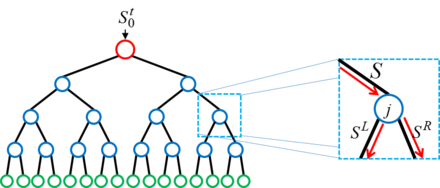

### Naive Bayes 분류

Naive Bayes 분류는 특성들 사이의 독립을 가정하는 베이즈 정리를 적용한 확률 분류기의 일종으로 1950년대 이후 광범위하게 연구되고 있다[5]. 통계 및 컴퓨터 과학문헌에서, 나이브 베이즈는 단순 베이즈, 독립 베이즈를 포함한 다양한 이름으로 알려져 있으며, 1960년대 초에 텍스트 검색 커뮤니티에 다른 이름으로 소개되기도 하였다. Naive Bayes 분류는 텍스트 분류에 사용됨으로써 문서를 여러 범주 중 하나로 판단하는 문제에 대한 대중적인 방법으로 남아있다. 또한, 자동 의료 진단 분야에서의 응용사례를 보면, 적절한 전처리를 하면 더 진보된 방법들과도 충분한 경쟁력을 보임을 알 수 있다.

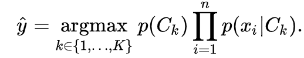

### Gradient Boosting

Gradient Boosting은 특히 회귀 및 분류 작업에 사용되는 기계학습 기술 입니다[6]. 일반적으로 결정 트리인 약한 예측 모델의 앙상블 형태로 예측 모델을 제공한다 . 결정 트리가 약한 학습기일 때 결과 알고리즘을 Gradeint Boost Tree라고 한다. Gradient Boost Tree모델은 다른 부스팅 방법 과 마찬가지로 단계적 방식으로 구축 되지만 임의의 최적화를 허용하여 다른 방법을 일반화한다.

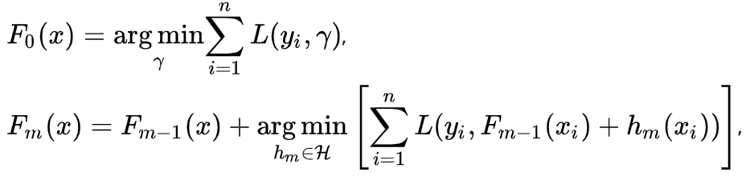

## 참고문헌

[1]이다영 (2019) “시공간적 패턴에 기반한 서울시 공공자전거 수요예측”, 석사학위논문  
[2]민소아, 정윤서(2021) “서울시 공공공자전거 수요예측 모형 비교 연구”. 한국데이터정보과학회지  
[3]이은탁, 손봉수 (2019), “이용수요 기반의 서울시 공공자전거 재배치전략 도출”, 대한교통학회지, Vol.37, No,1, pg 22-38  
[4]위키백과, “Random Forest”https://ko.wikipedia.org/wiki/%EB%9E%9C%EB%8D%A4_%ED%8F%AC%EB%A0%88%EC%8A%A4%ED%8A%B8  
[5]위키백과, “Naive Bayes”https://ko.wikipedia.org/wiki/%EB%82%98%EC%9D%B4%EB%B8%8C_%EB%B2%A0%EC%9D%B4%EC%A6%88_%EB%B6%84%EB%A5%98  
[6]위키백과, “Gradient Boosting” https://en.wikipedia.org/wiki/Gradient_boosting